# final project team 5

2022-12-11

# Investigation in DC crime trend 2016-2021

Professor: Dr. Farhana Faruqe

DATS-6101: Introduction to Data Science

Member: Xuanyu Chen, Yuchuan Feng, Ore Asaba, Kentaro Osawa, Adewale Maye

# Model

## Log-linear model

We calculated $\lambda$ without considering the effects of “Month”, “Weekday” and “District” in the midterm project. For final project, We will check these effects on the counts of each major crime using a Log-linear model.

In a Log-linear model, response variable is a count of some occurrence that follows a Poisson distribution, and explanatory variables are categorical variables. The expected counts $\mu_{ij}$ is modeled as follows:
$$\log(\mu_{ij})=\lambda + \lambda^A_i +
\lambda^B_j + \lambda^{AB}_{ij},$$
where $\lambda$ is a ground effect, $\lambda^A_i$ is the main effect of $i$ th level of A, and $\lambda^{AB}_{ij}$ is the interaction effect of $i$ th level of A and $j$ th level of B (if any) (https://online.stat.psu.edu/stat504/lesson/10).

# Method

First, We divided the data into two prats: pre-COVID (2016-2019) and post-COVID (2020-2021). Then, each major crime case was classified by “District” and “Weekend”. “District” has five levels (1D, 2D, 3D, 4D, 5D), and “Weekend” has two levels (0 (stands for weekday), 1 (stands for weekend)). DC area are divided by seven police districts, but We excluded sixth and seventh districts because these districts have a very low crime rate, which makes the analysis difficult.

We modeled the relationship between the counts of each major crime and categorical variables (“District” and “Weekend”) using four independence models and the saturated model:
$${\rm{Model \ 1:}} \
\log(\mu_{ij})=\lambda.$$
$${\rm{Model
\ 2:}} \ \log(\mu_{ij})=\lambda + \lambda^{District}_i.$$
$${\rm{Model \ 3:}} \ \log(\mu_{ij})=\lambda +
\lambda^{Weekend}_j.$$
$${\rm{Model \
4:}} \ \log(\mu_{ij})=\lambda + \lambda^{District}_i +
\lambda^{Weekend}_j.$$
$${\rm{Model \
5:}} \ \log(\mu_{ij})=\lambda + \lambda^{District}_i +
\lambda^{Weekend}_j + \lambda^{District,Weekend}_{ij}.$$

# Model Evaluation

## Simple Assault

The two-way tables for “Simple Assault” are as follows.

Two-way table by “District” and “Weekend”(pre-COVID)

|  | 0 | 1 |
| --- | --- | --- |
| 1D | 154 | 111 |
| 2D | 286 | 250 |
| 3D | 255 | 227 |
| 4D | 301 | 195 |
| 5D | 100 | 43 |

Two-way table by “District” and “Weekend” (post-COVID)

|  | 0 | 1 |
| --- | --- | --- |
| 1D | 44 | 31 |
| 2D | 111 | 67 |
| 3D | 96 | 51 |
| 4D | 103 | 78 |
| 5D | 32 | 22 |

### Deviance

We used “residual deviance” to test the below hypothesis at a significance level $\alpha=0.05$:
$$H_0: \ \rm{Reduced \ model \ is \
true.}$$
$$H_1: \ \rm{Satureated \
model \ (Model \ 5) \ is \ true.}$$
“residual deviance” is the difference between the deviance of the model and that of the saturated model. According to The Pennsylvania State University website (https://online.stat.psu.edu/stat504/lesson/6/6.3/6.3.4), “residual deviance” follows a chi-square distribution with the model’s degrees of freedom. Therefore, to test the hypothesis, I calculated p-values.

**pre-COVID**

| Model | Deviance | df | p-value |
| --- | --- | --- | --- |
| Model 1 | 404.6597586 | 9 | 1.3878932^{-81} |
| Model 2 | 57.2481754 | 5 | 4.4950187^{-11} |
| Model 3 | 366.6047721 | 8 | 2.5778957^{-74} |
| Model 4 | 19.1931889 | 4 | 7.2014228^{-4} |

$H_0$ is rejected for all models.

**post-COVID**

| Model | Deviance | df | p-value |
| --- | --- | --- | --- |
| Model 1 | 152.6545112 | 9 | 2.4850532^{-28} |
| Model 2 | 32.5805672 | 5 | 4.5584955^{-6} |
| Model 3 | 122.8633488 | 8 | 8.4911046^{-23} |
| Model 4 | 2.7894049 | 4 | 0.593663 |

For Model 4, $H_0$ is not rejected.

### AIC and BIC

Each model’s AIC and BIC was as follows.

**pre-COVID**

Model 5 is the best in terms of both AIC and BIC

| Model | AIC | BIC |
| --- | --- | --- |
| Model 1 | 476.2873304 | 476.5899155 |
| Model 2 | 136.8757472 | 138.3886727 |
| Model 3 | 440.2323439 | 440.8375141 |
| Model 4 | 100.8207607 | 102.6362712 |
| Model 5 | 89.6275718 | 92.6534228 |

**post-COVID**

Model 4 is the best in terms of both AIC and BIC.

| Model | AIC | BIC |
| --- | --- | --- |
| Model 1 | 213.2447669 | 213.5473519 |
| Model 2 | 101.1708229 | 102.6837483 |
| Model 3 | 185.4536045 | 186.0587747 |
| Model 4 | 73.3796605 | 75.195171 |
| Model 5 | 78.5902556 | 81.6161066 |

### Best Model

Saturated model is the best for pre-COVID model. On the other hand, Independence model is the best for post-COVID model.

#### Parameters

**pre-COVID**

Although the best model is the saturated model, almost all interaction terms are not significant. The interaction between “5D” and “weekend” is significant and has a negative value. This means the count of “Simple Assault” in 5D on weekend is fewer than the other districts.

Model: Count ~ District * Weekend

|  | Estimate | Std. Error | z value | Pr(>\|z\|) |
| --- | --- | --- | --- | --- |
| (Intercept) | 5.0370 | 0.0806 | 62.5069 | 0.0000 |
| District2D | 0.6190 | 0.1000 | 6.1935 | 0.0000 |
| District3D | 0.5043 | 0.1021 | 4.9416 | 0.0000 |
| District4D | 0.6702 | 0.0991 | 6.7642 | 0.0000 |
| District5D | -0.4318 | 0.1284 | -3.3621 | 0.0008 |
| Weekend1 | -0.3274 | 0.1245 | -2.6297 | 0.0085 |
| District2D:Weekend1 | 0.1929 | 0.1517 | 1.2719 | 0.2034 |
| District3D:Weekend1 | 0.2111 | 0.1544 | 1.3676 | 0.1714 |
| District4D:Weekend1 | -0.1067 | 0.1548 | -0.6893 | 0.4906 |
| District5D:Weekend1 | -0.5165 | 0.2208 | -2.3393 | 0.0193 |

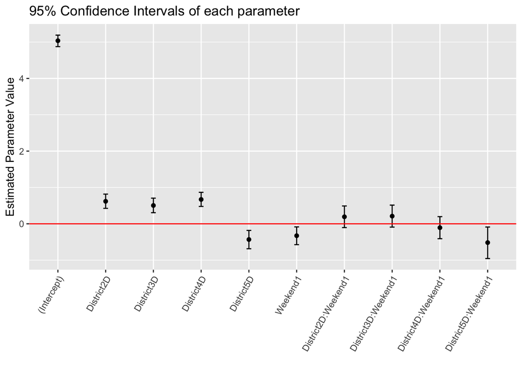

**post-COVID**

Model: Count ~ District + Weekend

|  | Estimate | Std. Error | z value | Pr(>\|z\|) |
| --- | --- | --- | --- | --- |
| (Intercept) | 3.8197 | 0.1198 | 31.8871 | 0.0000 |
| District2D | 0.8643 | 0.1377 | 6.2783 | 0.0000 |
| District3D | 0.6729 | 0.1419 | 4.7423 | 0.0000 |
| District4D | 0.8810 | 0.1373 | 6.4155 | 0.0000 |
| District5D | -0.3285 | 0.1785 | -1.8407 | 0.0657 |
| Weekend1 | -0.4384 | 0.0813 | -5.3934 | 0.0000 |

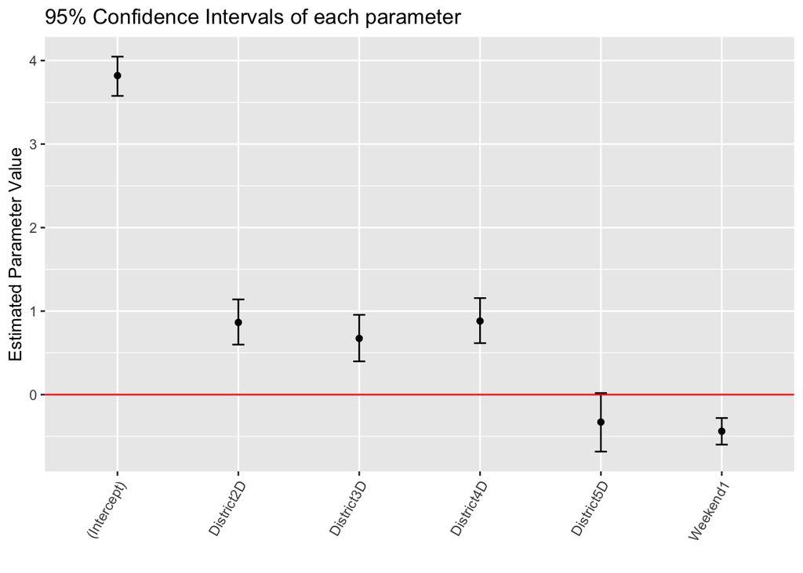

## Traffic Violations

Two-way table by “District” and “Weekend”(pre-COVID)

|  | 0 | 1 |
| --- | --- | --- |
| 1D | 103 | 39 |
| 2D | 244 | 101 |
| 3D | 144 | 66 |
| 4D | 229 | 118 |
| 5D | 130 | 52 |

Two-way table by “District” and “Weekend” (post-COVID)

|  | 0 | 1 |
| --- | --- | --- |
| 1D | 10 | 7 |
| 2D | 73 | 27 |
| 3D | 18 | 9 |
| 4D | 35 | 4 |
| 5D | 9 | 3 |

### Deviance

I tested the below hypothesis at a significance level $\alpha=0.05$:
$$H_0: \ \rm{Reduced \ model \ is \ true.}$$
$$H_1: \ \rm{Satureated \ model \ (Model \ 5)
\ is \ true.}$$

**pre-COVID**

| Model | Deviance | df | p-value |
| --- | --- | --- | --- |
| Model 1 | 339.2505658 | 9 | 1.2001869^{-67} |
| Model 2 | 191.3609877 | 5 | 1.9993045^{-39} |
| Model 3 | 151.1285587 | 8 | 1.1402548^{-28} |
| Model 4 | 3.2389807 | 4 | 0.518658 |

$H_0$ is not rejected for Model 4.

**post-COVID**

| Model | Deviance | df | p-value |
| --- | --- | --- | --- |
| Model 1 | 168.9249325 | 9 | 1.0333557^{-31} |
| Model 2 | 56.9799249 | 5 | 5.105366^{-11} |
| Model 3 | 120.6122741 | 8 | 2.477926^{-22} |
| Model 4 | 8.6672665 | 4 | 0.0699762 |

$H_0$ is not rejected for Model 4.

### AIC and BIC

Each model’s AIC and BIC was as follows.

**pre-COVID**

Model 4 is the best in terms of AIC and BIC.

| Model | AIC | BIC |
| --- | --- | --- |
| Model 1 | 406.2411034 | 406.5436885 |
| Model 2 | 266.3515254 | 267.8644508 |
| Model 3 | 220.1190964 | 220.7242665 |
| Model 4 | 80.2295183 | 82.0450289 |
| Model 5 | 84.9905376 | 88.0163886 |

**post-COVID**

Model 5 is the best in terms of AIC, but Model 4 is the best from BIC. According to Chakrabarti & Ghosh (2011), “The Bayesian Information Criterion (BIC) is more useful in selecting a correct model while the AIC is more appropriate in finding the best model for predicting future observations.” I want to select the correct model, not a model with high predictive power, so I will focus on the BIC results.

| Model | AIC | BIC |
| --- | --- | --- |
| Model 1 | 214.6604597 | 214.9630448 |
| Model 2 | 110.715452 | 112.2283775 |
| Model 3 | 168.3478013 | 168.9529715 |
| Model 4 | 64.4027936 | 66.2183042 |
| Model 5 | 63.7355272 | 66.7613781 |

### Best Model

Independence model is the best for pre-COVID and post-COVID.

#### Parameters

**pre-COVID**

Model: Count ~ District + Weekend

|  | Estimate | Std. Error | z value | Pr(>\|z\|) |
| --- | --- | --- | --- | --- |
| (Intercept) | 4.5896 | 0.0860 | 53.3415 | 0.0000 |
| District2D | 0.8877 | 0.0997 | 8.9036 | 0.0000 |
| District3D | 0.3913 | 0.1086 | 3.6014 | 0.0003 |
| District4D | 0.8935 | 0.0996 | 8.9691 | 0.0000 |
| District5D | 0.2482 | 0.1120 | 2.2165 | 0.0267 |
| Weekend1 | -0.8156 | 0.0619 | -13.1693 | 0.0000 |

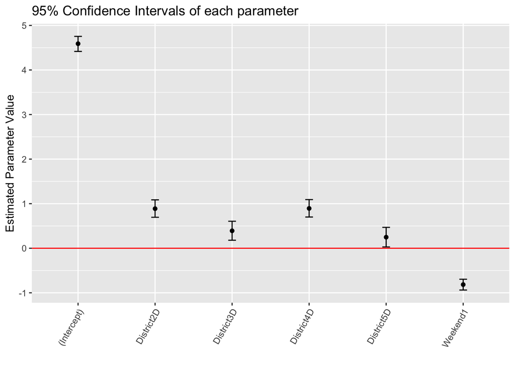

**post-COVID**

Model: Count ~ District + Weekend

|  | Estimate | Std. Error | z value | Pr(>\|z\|) |
| --- | --- | --- | --- | --- |
| (Intercept) | 2.5369 | 0.2462 | 10.3063 | 0.0000 |
| District2D | 1.7720 | 0.2623 | 6.7544 | 0.0000 |
| District3D | 0.4626 | 0.3096 | 1.4942 | 0.1351 |
| District4D | 0.8303 | 0.2906 | 2.8571 | 0.0043 |
| District5D | -0.3483 | 0.3770 | -0.9238 | 0.3556 |
| Weekend1 | -1.0647 | 0.1640 | -6.4921 | 0.0000 |

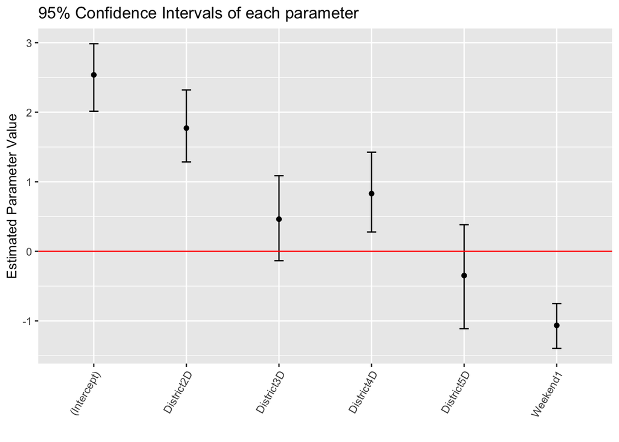

## Theft

Two-way table by “District” and “Weekend”(pre-COVID)

|  | 0 | 1 |
| --- | --- | --- |
| 1D | 55 | 25 |
| 2D | 126 | 43 |
| 3D | 118 | 37 |
| 4D | 70 | 22 |
| 5D | 63 | 25 |

Two-way table by “District” and “Weekend” (post-COVID)

|  | 0 | 1 |
| --- | --- | --- |
| 1D | 7 | 1 |
| 2D | 14 | 8 |
| 3D | 15 | 2 |
| 4D | 6 | 2 |
| 5D | 18 | 11 |

### Deviance

I tested the below hypothesis at a significance level $\alpha=0.05$:
$$H_0: \ \rm{Reduced \ model \ is \ true.}$$
$$H_1: \ \rm{Satureated \ model \ (Model \ 5)
\ is \ true.}$$

**pre-COVID**

| Model | Deviance | df | p-value |
| --- | --- | --- | --- |
| Model 1 | 200.1951983 | 9 | 3.015098^{-38} |
| Model 2 | 141.9038736 | 5 | 7.0457012^{-29} |
| Model 3 | 60.2642528 | 8 | 4.1364691^{-10} |
| Model 4 | 1.972928 | 4 | 0.7407383 |

$H_0$ is not rejected for Model 4.

**post-COVID**

| Model | Deviance | df | p-value |
| --- | --- | --- | --- |
| Model 1 | 41.9593618 | 9 | 3.3432429^{-6} |
| Model 2 | 21.7706056 | 5 | 5.7886223^{-4} |
| Model 3 | 26.0199263 | 8 | 0.0010421 |
| Model 4 | 5.8311701 | 4 | 0.2121164 |

$H_0$ is not rejected for Model 4.

### AIC and BIC

Each model’s AIC and BIC was as follows.

**pre-COVID**

Model 4 is the best in terms of AIC and BIC.

| Model | AIC | BIC |
| --- | --- | --- |
| Model 1 | 259.5208908 | 259.8234759 |
| Model 2 | 209.2295661 | 210.7424915 |
| Model 3 | 121.5899453 | 122.1951155 |
| Model 4 | 71.2986205 | 73.1141311 |
| Model 5 | 77.3256925 | 80.3515434 |

**post-COVID**

Model 4 is the best in terms of AIC and BIC.

| Model | AIC | BIC |
| --- | --- | --- |
| Model 1 | 80.6241843 | 80.9267694 |
| Model 2 | 68.4354281 | 69.9483536 |
| Model 3 | 66.6847489 | 67.2899191 |
| Model 4 | 54.4959927 | 56.3115032 |
| Model 5 | 56.6648225 | 59.6906735 |

### Best Model

**pre-COVID**

Model: Count ~ District + Weekend

|  | Estimate | Std. Error | z value | Pr(>\|z\|) |
| --- | --- | --- | --- | --- |
| (Intercept) | 4.0806 | 0.1145 | 35.6486 | 0.0000 |
| District2D | 0.7479 | 0.1357 | 5.5108 | 0.0000 |
| District3D | 0.6614 | 0.1377 | 4.8044 | 0.0000 |
| District4D | 0.1398 | 0.1529 | 0.9142 | 0.3606 |
| District5D | 0.0953 | 0.1545 | 0.6170 | 0.5372 |
| Weekend1 | -1.0445 | 0.0943 | -11.0760 | 0.0000 |

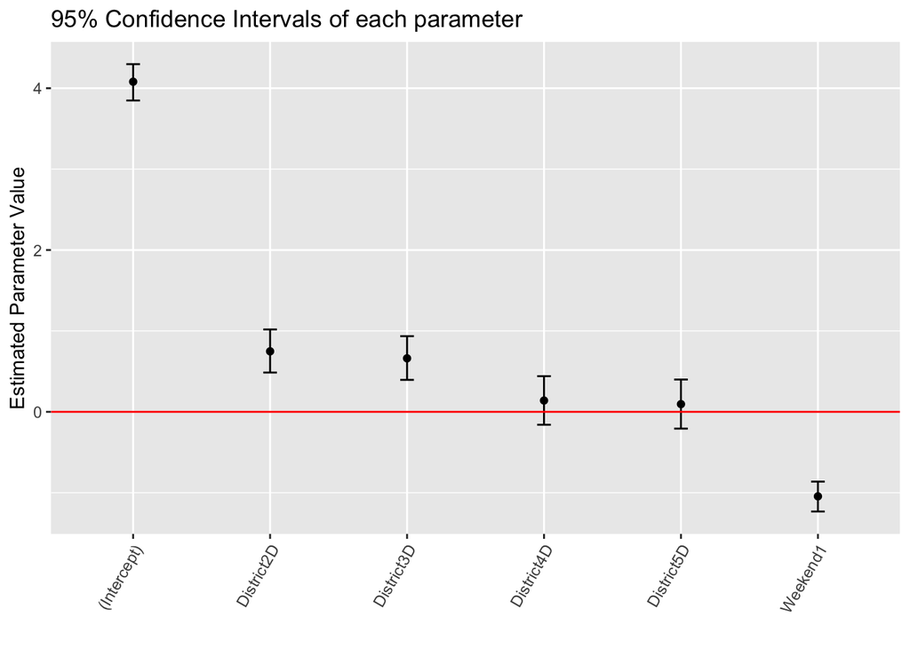

**post-COVID**

Model: Count ~ District + Weekend

|  | Estimate | Std. Error | z value | Pr(>\|z\|) |
| --- | --- | --- | --- | --- |
| (Intercept) | 1.7430 | 0.3602 | 4.8386 | 0.0000 |
| District2D | 1.0116 | 0.4129 | 2.4502 | 0.0143 |
| District3D | 0.7538 | 0.4287 | 1.7581 | 0.0787 |
| District4D | 0.0000 | 0.5000 | 0.0000 | 1.0000 |
| District5D | 1.2879 | 0.3994 | 3.2249 | 0.0013 |
| Weekend1 | -0.9163 | 0.2415 | -3.7938 | 0.0001 |

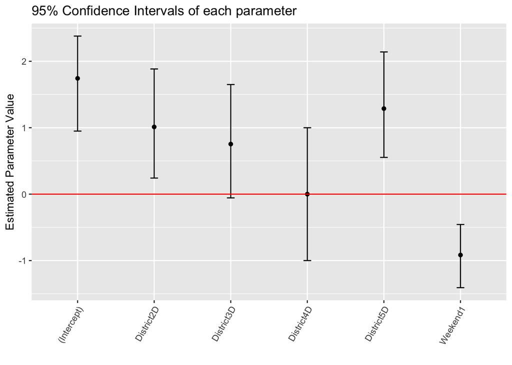

# Interpretation

# Conclusion

COVID-19 appears to not only reduce the number of crimes, but also change crime trends. In particular, 5D seems to have changed crime trends compared to other districts.

# Refereances

- 6.3.4 - analysis of deviance and Model Selection: Stat 504. PennState: Statistics Online Courses. (n.d.). Retrieved December 11, 2022, from https://online.stat.psu.edu/stat504/lesson/6/6.3/6.3.4
- 10: Log-Linear Models: Stat 504. PennState: Statistics Online Courses. (n.d.). Retrieved December 10, 2022, from https://online.stat.psu.edu/stat504/lesson/10
- Chakrabarti, A., & Ghosh, J. K. (2011). AIC, BIC and recent advances in model selection. Philosophy of statistics, 583-605.